# Statistical Analysis

## Producing complete tidy-data and handling the outlier

To analyze the effect hypothesized, we firstly combine all data together.

```r
# put all types of dataframe together to form a complete one:
aggregate_data <- inner_join(personality, visit_scale_score, by = "Key") %>%
  left_join(eye_data, by = c("Key", "Scenario", "Level of Vitality")) %>%
  select(RecordedDate, Key, `Level of Vitality`, Scenario, everything()) %>%
  mutate(`Level of Trust` = if_else(`Interpersonal Trust` >= median(.$`Interpersonal Trust`), "High", "Low") %>% factor()) %>% ungroup()
```

We try to kick the outliers. Eye-tracking metrics seldom follow normal distribution, therefore the criteria of outliers is based on distribution of data rather than standardized *Z*-score.

```r
# outlier removing function
remove_outliers <- function(x, na.rm = TRUE, ...) {
  qnt <- quantile(x, probs=c(.25, .75), na.rm = na.rm, ...)
  H <- 1.5 * IQR(x, na.rm = na.rm)
  y <- x
  y[x < (qnt[1] - H)] <- NA
  y[x > (qnt[2] + H)] <- NA
  y
}

# apply the function to DV
aggregate_data_screen <- aggregate_data %>% mutate_at(vars(Satisfaction:Vitality_attention_standardized), remove_outliers)
```

## Analysis: adjunctive stat analysis

By drawing the graph, we could see the distribution of the data, maybe giving us insights for later analysis.

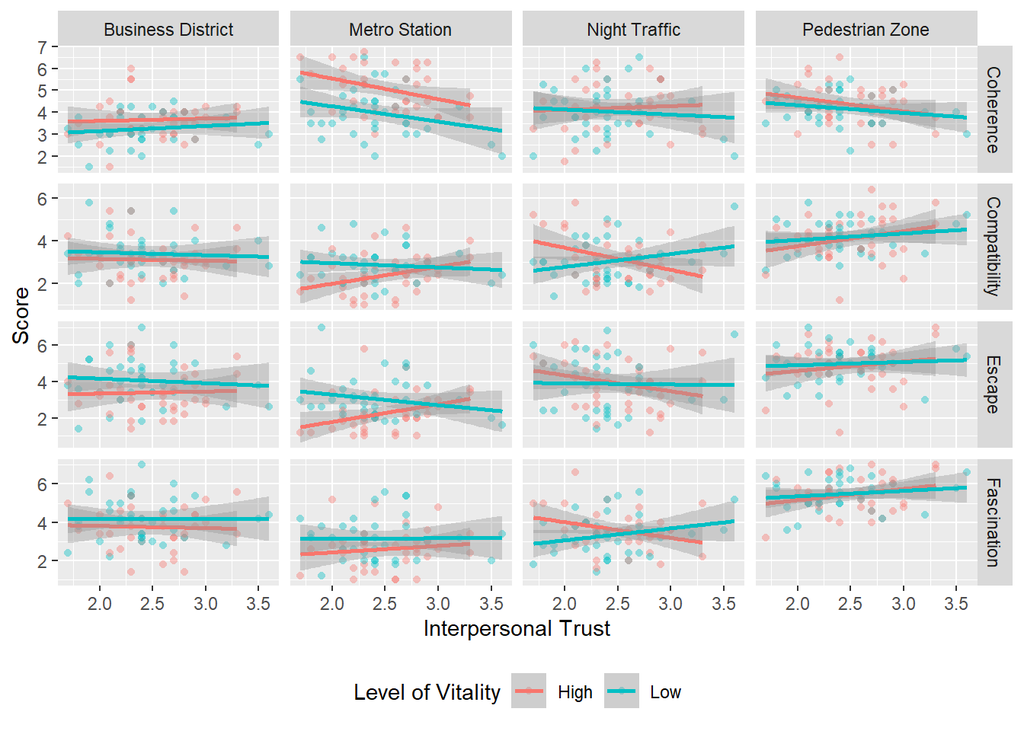

```r
# exploratory data insight: ggplot to find hidden rules.
# for different scenario and PRS subscale: facet 4 by 4.
ggplot(data = aggregate_data_screen %>% gather(Escape:Compatibility, key = 'variable', value = 'Score'),
       aes(x = `Interpersonal Trust`, y = Score)) +
  geom_point(aes(color = `Level of Vitality`),  shape = 16, alpha = 0.4) +
  geom_smooth(aes(color = `Level of Vitality`), method = "lm") +
  facet_grid(variable ~ Scenario, scales = "free_y") +
  theme(legend.position = "bottom")
```

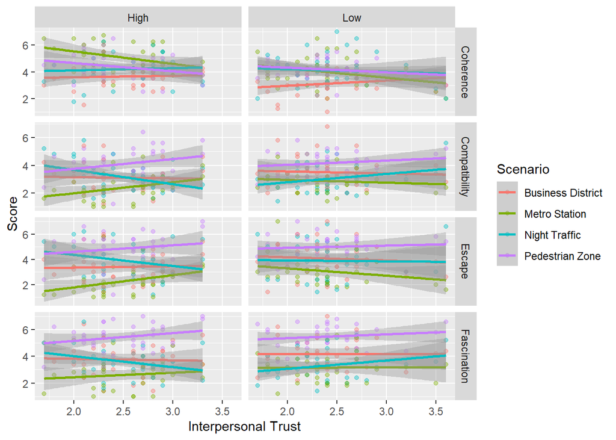

```r
# for different vitality level and PRS subscale: facet 2 by 4
ggplot(data = aggregate_data %>% gather(Escape:Compatibility, key = 'variable', value = 'Score'),
       aes(x = `Interpersonal Trust`, y = Score)) +
  geom_point(aes(color = `Scenario`),  alpha = 0.4) +
  geom_smooth(aes(color = `Scenario`), method = "lm") +
  facet_grid(variable ~ `Level of Vitality`, scales = "free_y")
```

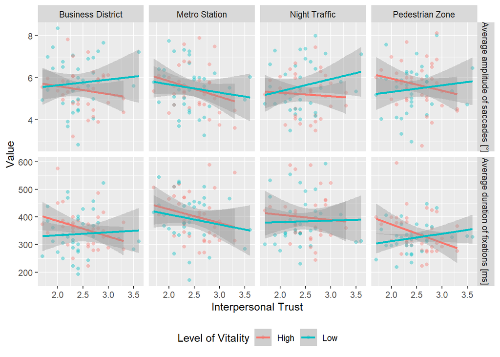

```r
# fixation is significant
ggplot(aggregate_data_screen %>%
         gather(Average_duration_of_whole_fixations, Average_amplitude_of_saccades, key = 'variable', value = 'Score') %>%
         mutate(variable = fct_relabel(variable, ~ str_replace_all(., '_', ' ') %>%
                                         str_remove(., ' whole') %>% paste(c("[°]", "[ms]")))),
       aes(x = `Interpersonal Trust`, y = Score)) +
  geom_point(aes(color = `Level of Vitality`), shape = 16, alpha = 0.4) +
  geom_smooth(aes(color = `Level of Vitality`), method = "lm") +
  scale_y_continuous(name = "Value") +
  facet_grid(variable ~ Scenario, scales = "free_y") +
  theme(legend.position = "bottom")
```

Firstly, we want to ensure whether all four dimension of PRS scale can properly reflect the restoration construct, which predict satisfaction based on ART.

```r
aggregate_data %>% select(Satisfaction:Compatibility) %>% corr.test(use = "pairwise")
```

```
## Call:corr.test(x = ., use = "pairwise")
## Correlation matrix
##               Satisfaction Escape Fascination Coherence Compatibility
## Satisfaction          1.00   0.81        0.79     -0.43          0.80
## Escape                0.81   1.00        0.72     -0.42          0.81
## Fascination           0.79   0.72        1.00     -0.22          0.76
## Coherence            -0.43  -0.42       -0.22      1.00         -0.41
## Compatibility         0.80   0.81        0.76     -0.41          1.00
## Sample Size
## [1] 287
## Probability values (Entries above the diagonal are adjusted for multiple tests.)
##               Satisfaction Escape Fascination Coherence Compatibility
## Satisfaction             0      0           0         0             0
## Escape                   0      0           0         0             0
## Fascination              0      0           0         0             0
## Coherence                0      0           0         0             0
## Compatibility            0      0           0         0             0
##
##  To see confidence intervals of the correlations, print with the short=FALSE option
```

Next, we want to explore the relationship between restoration and visual attention level. According to attention restorative theory, one will pay more involuntary attention to the environment if it is perceived as restorative. Yet we need a single metric to represent restoration level… maybe PCA is a good idea?

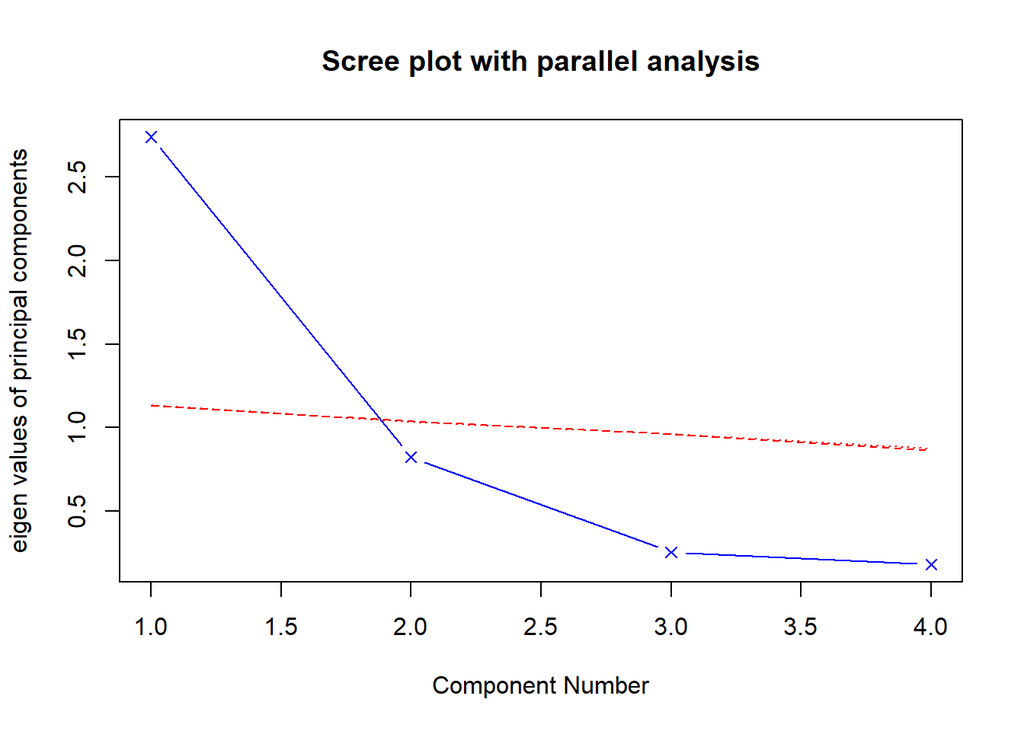

```
## Parallel analysis suggests that the number of factors =  NA  and the number of components =  1
```

```r
# aggregate_data, yyds.
for_pca <- aggregate_data %>% select(Escape:Compatibility)
# Scree plot: how many components should be extracted?
fa.parallel(for_pca, fa="pc", n.iter=100, show.legend=FALSE, main="Scree plot with parallel analysis")
```

```r
# principal analysis and output the principal score.
pca <- principal(for_pca, nfactors = 1, scores = TRUE)
aggregate_data_plus <- aggregate_data %>% mutate(Restoration = pca$scores)

# Compute the correlation to verify the ART.
aggregate_data_plus %>% select(Total_duration_of_whole_fixations:Saccade_frequency, Average_pupil_size) %>%
  map(~ cor.test(., aggregate_data_plus$Restoration))
```

```
## $Total_duration_of_whole_fixations
##
##  Pearson's product-moment correlation
##
## data:  . and aggregate_data_plus$Restoration
## t = -0.23443, df = 285, p-value = 0.8148
## alternative hypothesis: true correlation is not equal to 0
## 95 percent confidence interval:
##  -0.1294577  0.1020601
## sample estimates:
##         cor
## -0.01388489
##
##
## $Average_duration_of_whole_fixations
##
##  Pearson's product-moment correlation
##
## data:  . and aggregate_data_plus$Restoration
## t = -3.3702, df = 285, p-value = 0.0008549
## alternative hypothesis: true correlation is not equal to 0
## 95 percent confidence interval:
##  -0.3046440 -0.0818424
## sample estimates:
##        cor
## -0.1957682
##
##
## $Number_of_whole_fixations
##
##  Pearson's product-moment correlation
##
## data:  . and aggregate_data_plus$Restoration
## t = 3.2494, df = 285, p-value = 0.001295
## alternative hypothesis: true correlation is not equal to 0
## 95 percent confidence interval:
##  0.07486404 0.29826063
## sample estimates:
##       cor
## 0.1890067
```

[output cut: 111 more lines]

```
## 0.1564466
##
##
## $Average_pupil_size
##
##  Pearson's product-moment correlation
##
## data:  . and aggregate_data_plus$Restoration
## t = -2.6674, df = 285, p-value = 0.008082
## alternative hypothesis: true correlation is not equal to 0
## 95 percent confidence interval:
##  -0.26702192 -0.04102637
## sample estimates:
##        cor
## -0.1560659
```

```r
# another coding style...
corr.test(aggregate_data_plus %>% select(Restoration), aggregate_data_plus %>% select(Total_duration_of_whole_fixations:Saccade_frequency, Average_pupil_size), use = "pairwise.complete.obs")
```

```
## Call:corr.test(x = aggregate_data_plus %>% select(Restoration), y = aggregate_data_plus %>%
##     select(Total_duration_of_whole_fixations:Saccade_frequency,
##         Average_pupil_size), use = "pairwise.complete.obs")
## Correlation matrix
##             Total_duration_of_whole_fixations
## Restoration                             -0.01
##             Average_duration_of_whole_fixations Number_of_whole_fixations
## Restoration                                -0.2                      0.19
##             Number_of_saccades Average_peak_velocity_of_saccades
## Restoration               0.16                             -0.05
##             Standard_deviation_of_peak_velocity_of_saccades
## Restoration                                               0
##             Average_amplitude_of_saccades Total_amplitude_of_saccades
## Restoration                         -0.01                        0.13
##             Fixation_frequency Duration_proportion_of_fixations
## Restoration               0.19                            -0.01
##             Saccade_frequency Average_pupil_size
## Restoration              0.16              -0.16
## Sample Size
##     Total_duration_of_whole_fixations Average_duration_of_whole_fixations
## PC1                               287                                 287
##     Number_of_whole_fixations Number_of_saccades
## PC1                       287                287
##     Average_peak_velocity_of_saccades
## PC1                               287
##     Standard_deviation_of_peak_velocity_of_saccades
## PC1                                             286
##     Average_amplitude_of_saccades Total_amplitude_of_saccades
## PC1                           287                         287
##     Fixation_frequency Duration_proportion_of_fixations Saccade_frequency
## PC1                287                              287               287
##     Average_pupil_size
## PC1                287
## Probability values  adjusted for multiple tests.
##             Total_duration_of_whole_fixations
## Restoration                                 1
##             Average_duration_of_whole_fixations Number_of_whole_fixations
## Restoration                                0.01                      0.01
##             Number_of_saccades Average_peak_velocity_of_saccades
## Restoration               0.07                                 1
##             Standard_deviation_of_peak_velocity_of_saccades
## Restoration                                               1
##             Average_amplitude_of_saccades Total_amplitude_of_saccades
## Restoration                             1                        0.15
##             Fixation_frequency Duration_proportion_of_fixations
## Restoration               0.01                                1
##             Saccade_frequency Average_pupil_size
## Restoration              0.07               0.07
##
##  To see confidence intervals of the correlations, print with the short=FALSE option
```

Analysis the gender difference:

```r
participant <- read_csv("participant.csv", col_types = cols(
  gender = col_factor(levels = c("0", "1")),
  Participant = col_character())) %>% select(-Recording) %>% unique()

aggregate_data_plus %<>% left_join(participant, by = c("Key" = "Participant")) %>%
  mutate(gender = factor(gender, labels = c("Female", "Male"))) %>%
  select(RecordedDate, Key, Name, Gender = gender, Scenario:Compatibility, Restoration, everything())

# three_factor_aov <- aov(Restoration ~ Scenario * Gender * `Level of Vitality` + Error(Key/Scenario), data = aggregate_data_plus)

# repeated-measure anova: using Anova() in car package.
aggregate_data_wide <- aggregate_data_plus %>% select(Key, Name, `Level of Vitality`, Scenario, Gender, Restoration) %>% spread(Scenario, Restoration)
fit_repeated <- lm(cbind(`Business District`, `Metro Station`, `Night Traffic`, `Pedestrian Zone`) ~ Gender * `Level of Vitality`, data = aggregate_data_wide)
in_repeated <- expand.grid(`Scenario` = c("Business District", "Metro Station", "Night Traffic", "Pedestrian Zone"))
three_factor_aov <- Anova(fit_repeated, idata = in_repeated, idesign = ~ Scenario, type = 'III')
summary(three_factor_aov, multivariate = FALSE, univariate = TRUE)
```

```
##
## Univariate Type III Repeated-Measures ANOVA Assuming Sphericity
##
##                                     Sum Sq num Df Error SS den Df F value
## (Intercept)                          1.090      1   47.751     67  1.5291
## Gender                               0.701      1   47.751     67  0.9830
## `Level of Vitality`                  0.611      1   47.751     67  0.8570
## Gender:`Level of Vitality`           5.916      1   47.751     67  8.3010
## Scenario                            45.969      3  124.982    201 24.6427
## Gender:Scenario                      1.865      3  124.982    201  0.9998
## `Level of Vitality`:Scenario         3.214      3  124.982    201  1.7229
## Gender:`Level of Vitality`:Scenario  0.935      3  124.982    201  0.5013
##                                        Pr(>F)
## (Intercept)                          0.220570
## Gender                               0.325039
## `Level of Vitality`                  0.357896
## Gender:`Level of Vitality`           0.005318 **
## Scenario                            1.274e-13 ***
## Gender:Scenario                      0.394023
## `Level of Vitality`:Scenario         0.163507
## Gender:`Level of Vitality`:Scenario  0.681794
## ---
## Signif. codes:  0 '***' 0.001 '**' 0.01 '*' 0.05 '.' 0.1 ' ' 1
##
##
## Mauchly Tests for Sphericity
##
##                                     Test statistic p-value
## Scenario                                   0.88422 0.15154
## Gender:Scenario                            0.88422 0.15154
## `Level of Vitality`:Scenario               0.88422 0.15154
## Gender:`Level of Vitality`:Scenario        0.88422 0.15154
##
##
## Greenhouse-Geisser and Huynh-Feldt Corrections
##  for Departure from Sphericity
##
##                                      GG eps Pr(>F[GG])
## Scenario                            0.92702  8.538e-13 ***
## Gender:Scenario                     0.92702     0.3900
## `Level of Vitality`:Scenario        0.92702     0.1677
## Gender:`Level of Vitality`:Scenario 0.92702     0.6678
## ---
## Signif. codes:  0 '***' 0.001 '**' 0.01 '*' 0.05 '.' 0.1 ' ' 1
##
##                                        HF eps   Pr(>F[HF])
## Scenario                            0.9712179 2.697689e-13
## Gender:Scenario                     0.9712179 3.924805e-01
## `Level of Vitality`:Scenario        0.9712179 1.651568e-01
## Gender:`Level of Vitality`:Scenario 0.9712179 6.763909e-01
```

```r
# confirm the interaction
# method 1: using function in package bruceR.
MANOVA(aggregate_data_plus %>% rename(Vitality = `Level of Vitality`), subID = "Key", dv = "Restoration",
       between = c("Gender", "Vitality"), within = "Scenario")
```

[output not shown]

```
## ANOVA Table:
## Dependent variable(s):      Restoration
## Between-subjects factor(s): Gender, Vitality
## Within-subjects factor(s):  Scenario
## Covariate(s):               -
## ─────────────────────────────────────────────────────────────────────────────────
##                              MS  MSE df1 df2     F     p           η2p [90% CI]
## ─────────────────────────────────────────────────────────────────────────────────
## Gender                     1.49 0.71   1  67  2.10  .152     0.030 [0.000, 0.125]
## Vitality                  10.22 0.71   1  67 14.33 <.001 *** 0.176 [0.059, 0.311]
## Gender:Vitality            5.92 0.71   1  67  8.30  .005 **  0.110 [0.020, 0.237]
## Scenario                  22.04 0.62   3 201 35.45 <.001 *** 0.346 [0.257, 0.420]
## Gender:Scenario            0.57 0.62   3 201  0.92  .430     0.014 [0.000, 0.039]
## Vitality:Scenario          2.07 0.62   3 201  3.32  .021 *   0.047 [0.004, 0.094]
## Gender:Vitality:Scenario   0.31 0.62   3 201  0.50  .682     0.007 [0.000, 0.024]
## ─────────────────────────────────────────────────────────────────────────────────
## MSE = Mean Square Error (an estimate of population variance σ2).
##
## ω2 = omega-squared = (SS - df1 * MSE) / (SST + MSE)
## η2 = eta-squared = SS / SST
## η2G = generalized eta-squared (see Olejnik & Algina, 2003)
## η2p = partial eta-squared = SS / (SS + SSE) = F * df1 / (F * df1 + df2)
## Cohen’s f = sqrt( η2p / (1 - η2p) )
##
## Levene’s Test for Homogeneity of Variance:
##
## Mauchly’s Test of Sphericity:
##                          Mauchly's W       p
## Scenario                     0.88422 0.15154
## Gender:Scenario              0.88422 0.15154
## Vitality:Scenario            0.88422 0.15154
## Gender:Vitality:Scenario     0.88422 0.15154
```

```r
# method 2: testInteractions().
# note: because the factor should contain space, we should rename all factors.
fit_repeated_v2 <- lm(cbind(CBD, Metro, Night, Pedestrian) ~ Gender * Vitality, data = aggregate_data_wide %>%
                        rename(Vitality = `Level of Vitality`, CBD = `Business District`,
                               Metro = `Metro Station`, Night = `Night Traffic`, Pedestrian = `Pedestrian Zone`))
in_repeated_v2 <- expand.grid(`Scenario` = c("CBD", "Metro", "Night", "Pedestrian"))
testInteractions(fit_repeated_v2, idata = in_repeated_v2, fixed = "Gender", across = "Vitality")
```

|  | Value | Df | test stat | approx F | num Df | den Df | Pr(>F) |
| --- | --- | --- | --- | --- | --- | --- | --- |
| Female | -0.1063542 | 1 | 0.0126298 | 0.8570203 | 1 | 67 | 0.3578964775 |
| Male | -0.7836877 | 1 | 0.1789097 | 14.5988156 | 1 | 67 | 0.0005872561 |

```r
testInteractions(fit_repeated_v2, idata = in_repeated_v2, fixed = "Vitality", across = "Gender")
```

|  | Value | Df | test stat | approx F | num Df | den Df | Pr(>F) |
| --- | --- | --- | --- | --- | --- | --- | --- |
| High | 0.1684608 | 1 | 0.01445877 | 0.9829501 | 1 | 67 | 0.32503870 |
| Low | -0.5088727 | 1 | 0.12771801 | 9.8100233 | 1 | 67 | 0.00514651 |

```r
# visualization
aggregate_data_summary <- aggregate_data_plus %>%
  select(Key, Gender, `Level of Vitality`, Restoration) %>%
  group_by(Gender, `Level of Vitality`) %>%
  summarise(mean = mean(Restoration, na.rm = TRUE),
            se = sd(Restoration, na.rm = TRUE) / (n()-1))
```

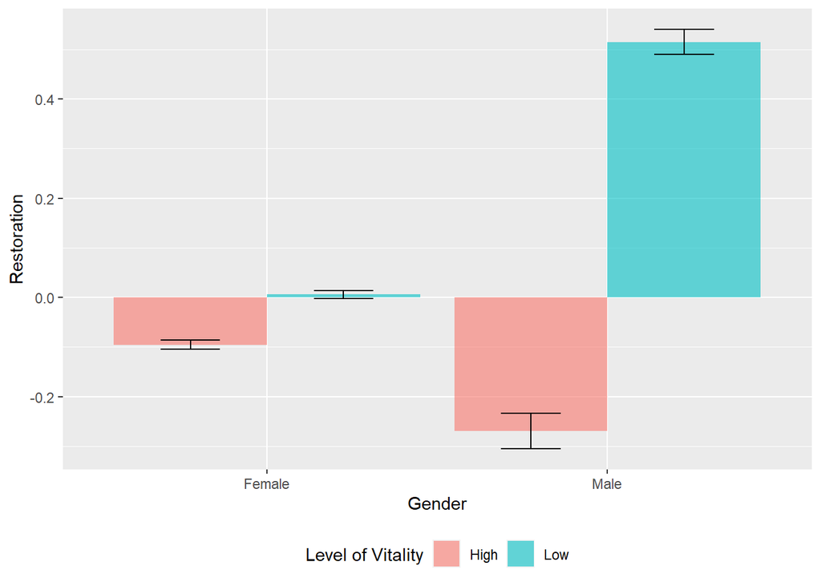

```r
ggplot(aggregate_data_summary, aes(x = Gender, y = mean, group = `Level of Vitality`)) +
  geom_bar(aes(fill = `Level of Vitality`), stat = "identity",
           position = "dodge", alpha = 0.60) +
  geom_errorbar(aes(ymin = mean-se, ymax = mean+se), stat = "identity",
                position = position_dodge(0.9), width = .35) +
  scale_y_continuous(name = "Restoration")+
  theme(legend.position = "bottom")
```

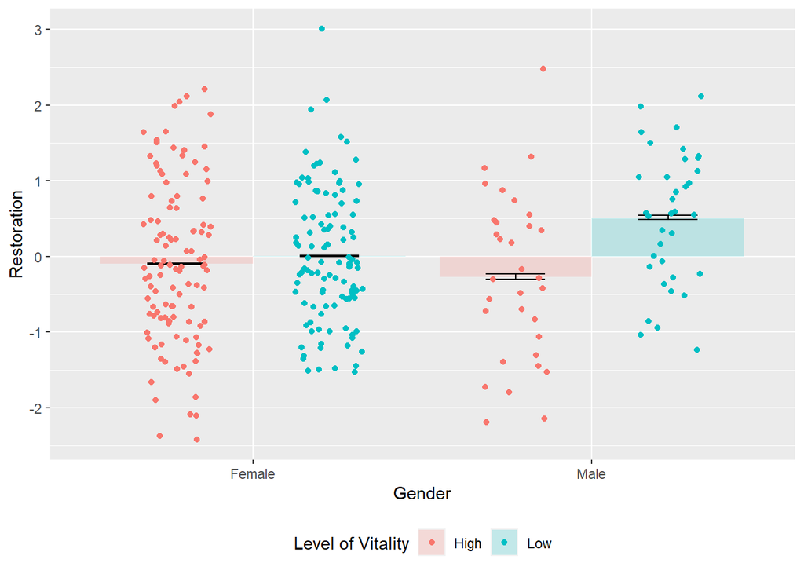

```r
ggplot(aggregate_data_summary, aes(x = Gender, y = mean, group = `Level of Vitality`)) +
  geom_bar(aes(fill = `Level of Vitality`), stat = "identity",
           position = "dodge", alpha = 0.20) +
  geom_errorbar(aes(ymin = mean-se, ymax = mean+se), stat = "identity",
                position = position_dodge(0.9), width = .35) +
  scale_y_continuous(name = "Restoration") +
  theme(legend.position = "bottom") +
  geom_point(aes(x = Gender, y = Restoration, color = `Level of Vitality`),
             data = aggregate_data_plus, position = position_jitterdodge(dodge.width = 0.9))
```

## Analysis: main hypothesis

Our plan is choosing all dependent variables to form a complete dataset. Then write a function for analyzing simply one column of dependent variable. All analyzing process would be iterated by **purrr::map()** function.

```r
# all dependent variables: dv_columns.
dv_columns <- aggregate_data_screen %>% select(Escape:Compatibility, Average_duration_of_whole_fixations, Average_peak_velocity_of_saccades, Average_amplitude_of_saccades, Average_pupil_size, Total_amplitude_of_saccades:Saccade_frequency, Vitality_attention, Vitality_attention_standardized)
dv_names <- names(dv_columns)
```

Therefore, a more advanced model is adopted. Hierarchical linear model (HLM) is suitable for analysis with great variance between groups. Here, sceanrio variable is regarded as grouping variable to seperate more variance.

```r
hlm_framework_v2 <- function(test_column){

  # HLM: hierarchical linear model:
  #   one dependent variable is picked up and added to the last column,
  #   to form a complete dataset named "restructured".

  restructured <- aggregate_data_screen %>% select(Key:`Interpersonal Trust`) %>% add_column(var = test_column) %>% rename(Vitality = `Level of Vitality`, Trust = `Interpersonal Trust`)

  # building the model.
  model2 <- lmer(var ~ Vitality * Trust + (1 | Scenario), data = restructured, na.action = na.exclude)
  # model3 <- lmer(var ~ Vitality * Trust + (1 | Scenario) + (1 | Key), data = restructured, na.action = na.exclude)
  # model_inter <- lmer(var ~ Vitality * Trust + (Vitality | Scenario), data = restructured, na.action = na.exclude)

  # return zone
  return(model2)
}
hlm_results <- dv_columns %>% map(hlm_framework_v2)
```

```
## boundary (singular) fit: see ?isSingular
## boundary (singular) fit: see ?isSingular
## boundary (singular) fit: see ?isSingular
```

```r
hlm_results %>% map(summary)
```

```
## $Escape
## Linear mixed model fit by REML. t-tests use Satterthwaite's method [
## lmerModLmerTest]
## Formula: var ~ Vitality * Trust + (1 | Scenario)
##    Data: restructured
##
## REML criterion at convergence: 951.5
##
## Scaled residuals:
##     Min      1Q  Median      3Q     Max
## -2.8203 -0.6836 -0.0665  0.6521  3.2401
##
## Random effects:
##  Groups   Name        Variance Std.Dev.
##  Scenario (Intercept) 0.8338   0.9131
##  Residual             1.5337   1.2384
## Number of obs: 287, groups:  Scenario, 4
##
## Fixed effects:
##                   Estimate Std. Error       df t value Pr(>|t|)
## (Intercept)         3.1619     0.8191  28.1598   3.860 0.000606 ***
## VitalityLow         1.2778     0.9057 279.9995   1.411 0.159400
## Trust               0.1824     0.2674 279.9995   0.682 0.495879
## VitalityLow:Trust  -0.3626     0.3619 279.9995  -1.002 0.317247
## ---
## Signif. codes:  0 '***' 0.001 '**' 0.01 '*' 0.05 '.' 0.1 ' ' 1
##
## Correlation of Fixed Effects:
##             (Intr) VtltyL Trust
## VitalityLow -0.623
## Trust       -0.821  0.742
## VtltyLw:Trs  0.606 -0.987 -0.739
##
## $Fascination
## Linear mixed model fit by REML. t-tests use Satterthwaite's method [
## lmerModLmerTest]
## Formula: var ~ Vitality * Trust + (1 | Scenario)
##    Data: restructured
##
## REML criterion at convergence: 871.7
```

[output cut: 415 more lines]

```
##
## Fixed effects:
##                   Estimate Std. Error       df t value Pr(>|t|)
## (Intercept)         3.5185     0.9141  55.0911   3.849 0.000311 ***
## VitalityLow        -0.5323     1.1237 253.0383  -0.474 0.636115
## Trust              -0.1506     0.3199 253.0232  -0.471 0.638199
## VitalityLow:Trust   0.4460     0.4491 253.0233   0.993 0.321677
## ---
## Signif. codes:  0 '***' 0.001 '**' 0.01 '*' 0.05 '.' 0.1 ' ' 1
##
## Correlation of Fixed Effects:
##             (Intr) VtltyL Trust
## VitalityLow -0.644
## Trust       -0.880  0.716
## VtltyLw:Trs  0.627 -0.986 -0.712
```

In fact, the results of HLM analysis is not good enough. From the exploratory plotting graph we can clearly see the influential pattern of data varies a lot among different scenarios. Thus we analyse the moderation effect separately within each scenario.

```r
scene_grouped <- aggregate_data_screen %>% split(.$Scenario)

moderation_on_one_scene <- function(one_scene){
  # center the moderate variable: ITS
  one_scene <- one_scene %>% mutate(`Interpersonal Trust Centered` = scale(`Interpersonal Trust`, center = TRUE, scale = TRUE))

  moderation_within_scene <- function(dv_name){
    #dv_name is a character string
    chosen <- one_scene %>% select(Vitality = `Level of Vitality`, Trust = `Interpersonal Trust Centered`, var = all_of(dv_name))

    fit0 <- lm(var ~ Vitality + Trust, data = chosen, na.action = na.exclude)
    fit1 <- lm(var ~ Vitality * Trust, data = chosen, na.action = na.exclude)
    comparison <- anova(fit0, fit1)
    return(list(fit0 = fit0, fit1 = fit1, compare = comparison))
  }

  fit_batch <- dv_names %>% map(moderation_within_scene)
  fit_batch <- fit_batch %>% set_names(dv_names)
  return(fit_batch)
}

fit_folded_batch <- scene_grouped %>% map(moderation_on_one_scene)
fit_folded_batch$`Business District` %>% map(~ map(., summary))
```

```
## $Escape
## $Escape$fit0
##
## Call:
## lm(formula = var ~ Vitality + Trust, data = chosen, na.action = na.exclude)
##
## Residuals:
##     Min      1Q  Median      3Q     Max
## -2.7259 -0.6889 -0.1907  0.7482  2.9263
##
## Coefficients:
##             Estimate Std. Error t value Pr(>|t|)
## (Intercept)  3.41535    0.20755  16.456   <2e-16 ***
## VitalityLow  0.65264    0.29457   2.216     0.03 *
## Trust       -0.03578    0.14832  -0.241     0.81
## ---
## Signif. codes:  0 '***' 0.001 '**' 0.01 '*' 0.05 '.' 0.1 ' ' 1
##
## Residual standard error: 1.241 on 69 degrees of freedom
## Multiple R-squared:  0.06968,    Adjusted R-squared:  0.04271
## F-statistic: 2.584 on 2 and 69 DF,  p-value: 0.08277
##
##
## $Escape$fit1
##
## Call:
## lm(formula = var ~ Vitality * Trust, data = chosen, na.action = na.exclude)
##
## Residuals:
##     Min      1Q  Median      3Q     Max
## -2.8274 -0.7205 -0.1404  0.7320  2.9236
##
## Coefficients:
##                   Estimate Std. Error t value Pr(>|t|)
## (Intercept)        3.40572    0.20959  16.250   <2e-16 ***
## VitalityLow        0.65426    0.29621   2.209   0.0306 *
## Trust              0.04554    0.22133   0.206   0.8376
## VitalityLow:Trust -0.14893    0.29954  -0.497   0.6206
## ---
## Signif. codes:  0 '***' 0.001 '**' 0.01 '*' 0.05 '.' 0.1 ' ' 1
```

[output cut: 873 more lines]

```
##  Min.   :68.00   Min.   :190.3   Min.   :1   Min.   :2.243   Min.   :0.8013
##  1st Qu.:68.25   1st Qu.:190.9   1st Qu.:1   1st Qu.:2.243   1st Qu.:0.8013
##  Median :68.50   Median :191.4   Median :1   Median :2.243   Median :0.8013
##  Mean   :68.50   Mean   :191.4   Mean   :1   Mean   :2.243   Mean   :0.8013
##  3rd Qu.:68.75   3rd Qu.:192.0   3rd Qu.:1   3rd Qu.:2.243   3rd Qu.:0.8013
##  Max.   :69.00   Max.   :192.6   Max.   :1   Max.   :2.243   Max.   :0.8013
##                                  NA's   :1   NA's   :1       NA's   :1
##      Pr(>F)
##  Min.   :0.3739
##  1st Qu.:0.3739
##  Median :0.3739
##  Mean   :0.3739
##  3rd Qu.:0.3739
##  Max.   :0.3739
##  NA's   :1
```

```r
fit_folded_batch$`Metro Station` %>% map(~ map(., summary))
```

```
## $Escape
## $Escape$fit0
##
## Call:
## lm(formula = var ~ Vitality + Trust, data = chosen, na.action = na.exclude)
##
## Residuals:
##     Min      1Q  Median      3Q     Max
## -1.6051 -0.8534 -0.2408  0.6588  4.0098
##
## Coefficients:
##             Estimate Std. Error t value Pr(>|t|)
## (Intercept)  2.27988    0.19320  11.800  < 2e-16 ***
## VitalityLow  0.78182    0.27230   2.871  0.00545 **
## Trust        0.05193    0.13624   0.381  0.70424
## ---
## Signif. codes:  0 '***' 0.001 '**' 0.01 '*' 0.05 '.' 0.1 ' ' 1
##
## Residual standard error: 1.139 on 68 degrees of freedom
##   (1 observation deleted due to missingness)
## Multiple R-squared:  0.1082, Adjusted R-squared:  0.08192
## F-statistic: 4.123 on 2 and 68 DF,  p-value: 0.02041
##
##
## $Escape$fit1
##
## Call:
## lm(formula = var ~ Vitality * Trust, data = chosen, na.action = na.exclude)
##
## Residuals:
##     Min      1Q  Median      3Q     Max
## -1.5673 -0.7388 -0.2939  0.3795  3.7206
##
## Coefficients:
##                   Estimate Std. Error t value Pr(>|t|)
## (Intercept)         2.2407     0.1874  11.958   <2e-16 ***
## VitalityLow         0.7867     0.2631   2.990   0.0039 **
## Trust               0.4009     0.1954   2.051   0.0442 *
## VitalityLow:Trust  -0.6387     0.2644  -2.415   0.0185 *
## ---
```

[output cut: 881 more lines]

```
##  Min.   :49.00   Min.   :73.00   Min.   :1   Min.   :7.074   Min.   :4.748
##  1st Qu.:49.25   1st Qu.:74.77   1st Qu.:1   1st Qu.:7.074   1st Qu.:4.748
##  Median :49.50   Median :76.53   Median :1   Median :7.074   Median :4.748
##  Mean   :49.50   Mean   :76.53   Mean   :1   Mean   :7.074   Mean   :4.748
##  3rd Qu.:49.75   3rd Qu.:78.30   3rd Qu.:1   3rd Qu.:7.074   3rd Qu.:4.748
##  Max.   :50.00   Max.   :80.07   Max.   :1   Max.   :7.074   Max.   :4.748
##                                  NA's   :1   NA's   :1       NA's   :1
##      Pr(>F)
##  Min.   :0.03417
##  1st Qu.:0.03417
##  Median :0.03417
##  Mean   :0.03417
##  3rd Qu.:0.03417
##  Max.   :0.03417
##  NA's   :1
```

```r
fit_folded_batch$`Night Traffic` %>% map(~ map(., summary))
```

```
## $Escape
## $Escape$fit0
##
## Call:
## lm(formula = var ~ Vitality + Trust, data = chosen, na.action = na.exclude)
##
## Residuals:
##     Min      1Q  Median      3Q     Max
## -2.5808 -1.3215  0.0794  0.9695  3.2214
##
## Coefficients:
##             Estimate Std. Error t value Pr(>|t|)
## (Intercept)  3.92675    0.23859  16.458   <2e-16 ***
## VitalityLow -0.05349    0.33862  -0.158    0.875
## Trust       -0.17908    0.17050  -1.050    0.297
## ---
## Signif. codes:  0 '***' 0.001 '**' 0.01 '*' 0.05 '.' 0.1 ' ' 1
##
## Residual standard error: 1.426 on 69 degrees of freedom
## Multiple R-squared:  0.01575,    Adjusted R-squared:  -0.01278
## F-statistic: 0.5522 on 2 and 69 DF,  p-value: 0.5782
##
##
## $Escape$fit1
##
## Call:
## lm(formula = var ~ Vitality * Trust, data = chosen, na.action = na.exclude)
##
## Residuals:
##      Min       1Q   Median       3Q      Max
## -2.50234 -1.29403 -0.06549  0.95805  2.90443
##
## Coefficients:
##                   Estimate Std. Error t value Pr(>|t|)
## (Intercept)        3.94827    0.23971  16.471   <2e-16 ***
## VitalityLow       -0.05712    0.33878  -0.169    0.867
## Trust             -0.36101    0.25315  -1.426    0.158
## VitalityLow:Trust  0.33320    0.34259   0.973    0.334
## ---
## Signif. codes:  0 '***' 0.001 '**' 0.01 '*' 0.05 '.' 0.1 ' ' 1
```

[output cut: 869 more lines]

```
##  Min.   :68.00   Min.   :18.61   Min.   :1   Min.   :0.0007812
##  1st Qu.:68.25   1st Qu.:18.61   1st Qu.:1   1st Qu.:0.0007812
##  Median :68.50   Median :18.61   Median :1   Median :0.0007812
##  Mean   :68.50   Mean   :18.61   Mean   :1   Mean   :0.0007812
##  3rd Qu.:68.75   3rd Qu.:18.61   3rd Qu.:1   3rd Qu.:0.0007812
##  Max.   :69.00   Max.   :18.61   Max.   :1   Max.   :0.0007812
##                                  NA's   :1   NA's   :1
##        F                Pr(>F)
##  Min.   :0.002854   Min.   :0.9576
##  1st Qu.:0.002854   1st Qu.:0.9576
##  Median :0.002854   Median :0.9576
##  Mean   :0.002854   Mean   :0.9576
##  3rd Qu.:0.002854   3rd Qu.:0.9576
##  Max.   :0.002854   Max.   :0.9576
##  NA's   :1          NA's   :1
```

[output not shown]

[output cut: 871 more lines]

```
##  Min.   :59.00   Min.   :131.2   Min.   :1   Min.   :0.5384   Min.   :0.2421
##  1st Qu.:59.25   1st Qu.:131.4   1st Qu.:1   1st Qu.:0.5384   1st Qu.:0.2421
##  Median :59.50   Median :131.5   Median :1   Median :0.5384   Median :0.2421
##  Mean   :59.50   Mean   :131.5   Mean   :1   Mean   :0.5384   Mean   :0.2421
##  3rd Qu.:59.75   3rd Qu.:131.6   3rd Qu.:1   3rd Qu.:0.5384   3rd Qu.:0.2421
##  Max.   :60.00   Max.   :131.8   Max.   :1   Max.   :0.5384   Max.   :0.2421
##                                  NA's   :1   NA's   :1        NA's   :1
##      Pr(>F)
##  Min.   :0.6246
##  1st Qu.:0.6246
##  Median :0.6246
##  Mean   :0.6246
##  3rd Qu.:0.6246
##  Max.   :0.6246
##  NA's   :1
```

[figure not shown]

```r
fit_folded_batch$`Pedestrian Zone` %>% map(~ map(., summary))
```

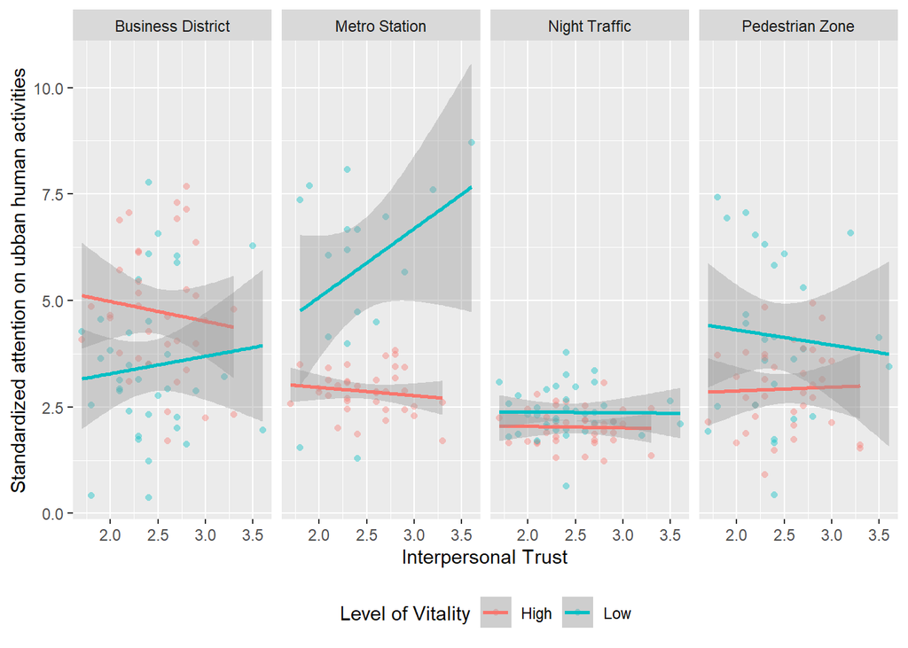

```r
ggplot(aggregate_data_screen, aes(x = `Interpersonal Trust`, y = Vitality_attention_standardized)) +
  geom_point(aes(color = `Level of Vitality`),  shape = 16, alpha = 0.4) +
  geom_smooth(aes(color = `Level of Vitality`), method = "lm") +
  scale_y_continuous(name = "Standardized attention on ubban human activities") +
  # facet_wrap( ~ Scenario, scales = "free_y", nrow = 2) +
  facet_grid( ~ Scenario, scales = "free_y") +
  theme(legend.position = "bottom")
```